# Lab 02 — Solutions: Intro to Census Data

PAF 516

```r
# Core packages for this lab
library( tidycensus )
library( tidyverse )   # includes ggplot2, dplyr, tidyr
library( viridis )     # color scales for maps
```

```r
# Uncomment and add your Census API key
# census_api_key("YOUR KEY GOES HERE")
```

# Step 1: Getting the Data

```r
# Search for variable names in the ACS 5-year data
VarSearch <- load_variables( 2017, "acs5", cache=TRUE )

# Convert all labels to upper case for easier searching
VarSearch$label <- toupper( VarSearch$label )

# Search for median house value variables
medianvalue <- VarSearch %>%
  mutate( contains.medianvalue = grepl( "MEDIAN VALUE", label ) ) %>%
  filter( contains.medianvalue )

# Search for median household income variables
medianincome <- VarSearch %>%
  mutate( contains.medianincome = grepl( "MEDIAN HOUSEHOLD INCOME", label ) ) %>%
  filter( contains.medianincome )
```

Now that these objects are created, we can take a look at what the variable search rendered:

```r
# View interactively to identify the correct variable codes
View( medianvalue )
View( medianincome )
```

After looking through the objects, we can see that `B19049_001` corresponds to the total median household income and `B25077_001` corresponds to the median house value.

```r
# Define variables with readable names using a named vector
vars.to.use <- c( HHIncome   = "B19049_001",
                  HouseValue = "B25077_001" )

# Retrieve county-level data with spatial geometry for mapping
CenDF <- get_acs( geography = "county",
                  year      = 2017,
                  survey    = "acs5",
                  variables = vars.to.use,
                  geometry  = TRUE )
```

# Step 2: Transforming the Data

```r
# Transform from long to wide format and compute the ratio
# NOTE: Using pivot_wider() instead of deprecated spread()
CenDF <- CenDF %>%
  select( -moe ) %>%
  pivot_wider( names_from = variable, values_from = estimate ) %>%
  mutate( HHInc_HousePrice_Ratio = HouseValue / HHIncome )
```

# Step 3: Data Exploration

```r
# Sort by ratio: lowest to highest (most affordable counties)
CenDF.lh <- CenDF %>%
  select( NAME, HHInc_HousePrice_Ratio ) %>%
  arrange( HHInc_HousePrice_Ratio )
head( CenDF.lh, 10 )
```

```
Simple feature collection with 10 features and 2 fields
Geometry type: MULTIPOLYGON
Dimension:     XY
Bounding box:  xmin: -104.1024 ymin: 26.59799 xmax: -97.29015 ymax: 43.70618
Geodetic CRS:  NAD83
# A tibble: 10 × 3
   NAME                         HHInc_HousePrice_Ratio                  geometry
   <chr>                                         <dbl>        <MULTIPOLYGON [°]>
 1 Oglala Lakota County, South…                  0.673 (((-103.001 43.60582, -1…
 2 King County, Texas                            0.681 (((-100.5187 33.83565, -…
 3 Kenedy County, Texas                          0.859 (((-97.39839 26.86789, -…
 4 Cochran County, Texas                         0.888 (((-103.0567 33.38844, -…
 5 Foard County, Texas                           0.948 (((-100.0476 34.0874, -1…
 6 Knox County, Texas                            0.959 (((-99.99643 33.83597, -…
 7 Hardeman County, Texas                        1.01  (((-99.99801 34.39682, -…
 8 McMullen County, Texas                        1.05  (((-98.80251 28.10305, -…
 9 Winkler County, Texas                         1.06  (((-103.3272 31.7819, -1…
10 Reeves County, Texas                          1.07  (((-104.101 31.12474, -1…
```

```r
# Sort by ratio: highest to lowest (least affordable counties)
CenDF.hl <- CenDF %>%
  select( NAME, HHInc_HousePrice_Ratio ) %>%
  arrange( desc( HHInc_HousePrice_Ratio ) )
head( CenDF.hl, 10 )
```

```
Simple feature collection with 10 features and 2 fields
Geometry type: MULTIPOLYGON
Dimension:     XY
Bounding box:  xmin: -123.0139 ymin: 36.85065 xmax: -69.96018 ymax: 44.6668
Geodetic CRS:  NAD83
# A tibble: 10 × 3
   NAME                         HHInc_HousePrice_Ratio                  geometry
   <chr>                                         <dbl>        <MULTIPOLYGON [°]>
 1 Kings County, New York                        11.8  (((-74.04201 40.62605, -…
 2 New York County, New York                     11.5  (((-73.9995 40.70033, -7…
 3 Nantucket County, Massachus…                  10.8  (((-70.23405 41.28565, -…
 4 Bronx County, New York                        10.2  (((-73.77336 40.85945, -…
 5 Dukes County, Massachusetts                    9.99 (((-70.8071 41.45858, -7…
 6 San Francisco County, Calif…                   9.63 (((-122.332 37.78776, -1…
 7 Teton County, Wyoming                          9.23 (((-111.0553 44.66626, -…
 8 Santa Cruz County, Californ…                   8.96 (((-122.3177 37.18695, -…
 9 Pitkin County, Colorado                        8.76 (((-107.466 39.32212, -1…
10 San Mateo County, California                   8.68 (((-122.5209 37.59418, -…
```

# Step 4: Map the Data

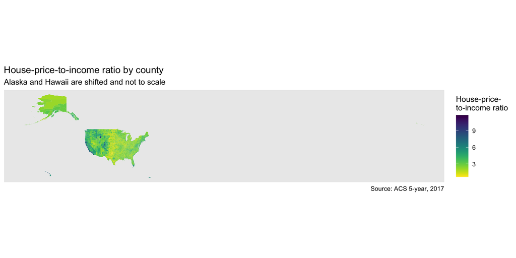

```r
# Create a choropleth map of the house-price-to-income ratio
ggplot( CenDF ) +
  geom_sf( aes( fill = HHInc_HousePrice_Ratio ), color = NA ) +
  coord_sf( datum = NA ) +
  labs( title    = "House-price-to-income ratio by county",
        subtitle = "Alaska and Hawaii are shifted and not to scale",
        caption  = "Source: ACS 5-year, 2017",
        fill     = "House-price-\nto-income ratio" ) +
  scale_fill_viridis( direction = -1 )
```

# Questions

### Question 1: Exploration.

1a. In step 3 above, what is the county with the highest (and lowest) house-price-to-income ratio? What is the average house-price-to-income ratio across all US counties over the time period?

- Answer: The county with the highest house-price-to-income ratio is Kings County, New York and the county with the lowest is Oglala Lakota County, South Dakota. The average ratio across all US counties is 2.83.

1b. Where is Maricopa County on the list? How many years of median income will it take to buy a home in Maricopa County?

- Answer: When looking from highest house-price-to-income to lowest, Maricopa County is 404 on the list and it will take 3.84 years of median income to buy a house.

1c. Where is Los Angeles on the list and how does its ranking compare to the list reported in the Citylab report?

- Answer: Los Angeles is 12 on the list from high to low. This departs from the article which lists LA as first.

### Question 2: Temporal analysis.

2a. Go back to Step 1 above, and enter in 2012 as the year value. Repeat Steps 2-4.

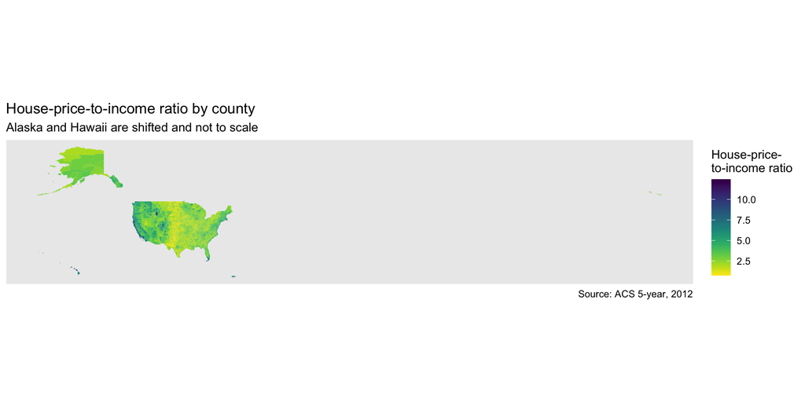

```r
# Retrieve 2008-2012 ACS data for temporal comparison
CenDF.12 <- get_acs( geography = "county",
                     year      = 2012,
                     survey    = "acs5",
                     variables = vars.to.use,
                     geometry  = TRUE )
# Transform and compute ratio (using pivot_wider, not spread)
CenDF.12 <- CenDF.12 %>%
  select( -moe ) %>%
  pivot_wider( names_from = variable, values_from = estimate ) %>%
  mutate( HHInc_HousePrice_Ratio = HouseValue / HHIncome )

# Sort for exploration
CenDF.12.lh <- CenDF.12 %>%
  select( NAME, HHInc_HousePrice_Ratio ) %>%
  arrange( HHInc_HousePrice_Ratio )

CenDF.12.hl <- CenDF.12 %>%
  select( NAME, HHInc_HousePrice_Ratio ) %>%
  arrange( desc( HHInc_HousePrice_Ratio ) )

# Map the 2012 data
ggplot( CenDF.12 ) +
  geom_sf( aes( fill = HHInc_HousePrice_Ratio ), color = NA ) +
  coord_sf( datum = NA ) +
  labs( title    = "House-price-to-income ratio by county",
        subtitle = "Alaska and Hawaii are shifted and not to scale",
        caption  = "Source: ACS 5-year, 2012",
        fill     = "House-price-\nto-income ratio" ) +
  scale_fill_viridis( direction = -1 )
```

- Answer: The county with the highest house-price-to-income ratio in 2012 is Kings County, New York and the county with the lowest is Shannon County, South Dakota.

2b. Compare and contrast the findings over the different time periods.

```r
# Prepare 2017 data for joining (drop geometry to join as data frames)
df.17 <- CenDF %>%
  sf::st_drop_geometry() %>%
  select( GEOID, HHInc_HousePrice_Ratio, NAME ) %>%
  rename( HHInc_HousePrice_Ratio.17 = HHInc_HousePrice_Ratio )

# Prepare 2012 data for joining
df.12 <- CenDF.12 %>%
  sf::st_drop_geometry() %>%
  select( GEOID, HHInc_HousePrice_Ratio ) %>%
  rename( HHInc_HousePrice_Ratio.12 = HHInc_HousePrice_Ratio )

# Join the two time periods
both.year <- full_join( df.17, df.12, by = "GEOID" )

# Compute the change score (2017 minus 2012)
both.year$HHInc_HousePrice_Ratio.d <-
  both.year$HHInc_HousePrice_Ratio.17 - both.year$HHInc_HousePrice_Ratio.12

# Summary statistics of the change
summary( both.year$HHInc_HousePrice_Ratio.d )
```

```
    Min.  1st Qu.   Median     Mean  3rd Qu.     Max.     NA's
-3.74830 -0.23114 -0.04869 -0.05630  0.13301  1.91569        7
```

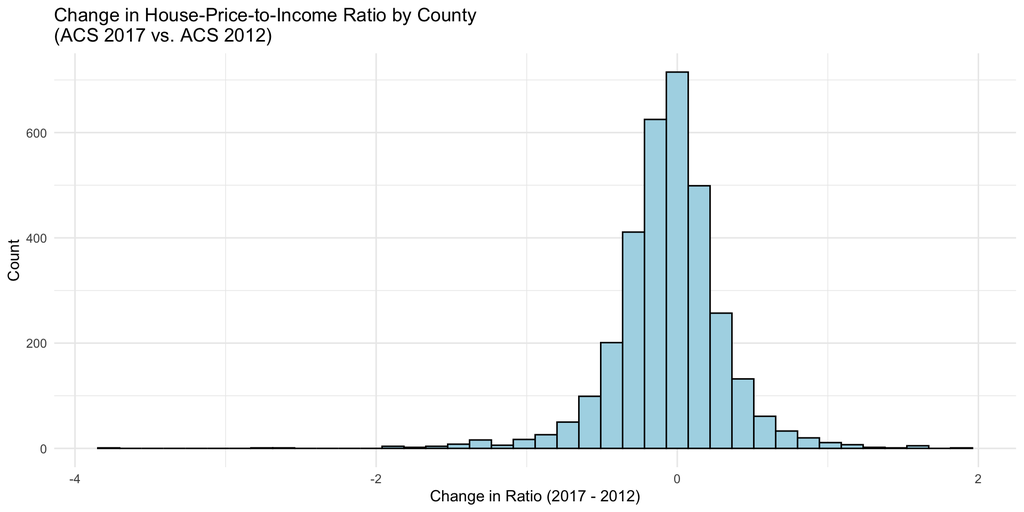

```r
# Histogram of the change in ratio
ggplot( both.year, aes( x = HHInc_HousePrice_Ratio.d ) ) +
  geom_histogram( color = "black", fill = "lightblue", bins = 40 ) +
  theme_minimal() +
  labs( title = "Change in House-Price-to-Income Ratio by County\n(ACS 2017 vs. ACS 2012)",
        x     = "Change in Ratio (2017 - 2012)",
        y     = "Count" )
```

- Answer: The overall change is close to zero, although the average decreased slightly. For Maricopa County, the change was 0.28, showing an increase from 2012 to 2017. As for Los Angeles county, there was an increase of 0.24.

### Question 3: High-Resolution Analysis.

3a. Change geography from `county` to `tract` for Maricopa County.

```r
# Retrieve tract-level data for Maricopa County only
CenDF.az <- get_acs( geography = "tract",
                     year      = 2017,
                     state     = "AZ",
                     county    = "Maricopa County",
                     survey    = "acs5",
                     variables = vars.to.use,
                     geometry  = TRUE )

# Transform and compute ratio (using pivot_wider, not spread)
CenDF.az <- CenDF.az %>%
  select( -moe ) %>%
  pivot_wider( names_from = variable, values_from = estimate ) %>%
  mutate( HHInc_HousePrice_Ratio = HouseValue / HHIncome )

# Summary statistics
summary( CenDF.az$HHInc_HousePrice_Ratio )
```

- Answer: Here are the summary statistics: the min is 0.31, the max is 14.2, the median is 3.33, the mean is 3.62, and the sd is 1.33.

3b. Compare and contrast the findings for the different levels of geography.

```r
# Build a comparison table: county-level vs tract-level statistics
compare.table <-
  rbind(
    # County-level info for Maricopa
    c( summary(
      CenDF$HHInc_HousePrice_Ratio[CenDF$NAME == "Maricopa County, Arizona"]
    ), 0 ),
    # Tract-level info for Maricopa
    summary( CenDF.az$HHInc_HousePrice_Ratio )
  )

rownames( compare.table ) <- c( "county", "tract" )
colnames( compare.table )[7] <- "NAs"

round( compare.table, 2 )
```

```
       Min. 1st Qu. Median Mean 3rd Qu.  Max. NAs
county 3.84    3.84   3.84 3.84    3.84  3.84   0
tract  0.31    2.85   3.33 3.62    4.13 14.20  24
```

- Answer: We can see that the measures of central tendency are similar. However, a major difference is with the ends of the distribution. The variation in the distributions is considerable when we compare the min/max for each level — tract-level data reveals much more heterogeneity within Maricopa County than the single county-level value suggests.